# Data Viz 2 - Homework 1

Cosmin Catalin Ticu

3/16/2021

Load the nycflights13 package and check what kind of datasets exist in the package, then create a copy of flights dataset into a data.table object, called flight_data.

```r
library(data.table)
library(nycflights13)
library(lubridate)
library(ggplot2)
# for the last question
library(cowplot)
library(rnaturalearth)
library(googleway)
library(rgeos)
library(rnaturalearthdata)
library(ggspatial)
library(sf)
library(ggrepel)

flight_data <- data.table(nycflights13::flights)

str(flight_data)
```

```
## Classes 'data.table' and 'data.frame':   336776 obs. of  19 variables:
##  $ year          : int  2013 2013 2013 2013 2013 2013 2013 2013 2013 2013 ...
##  $ month         : int  1 1 1 1 1 1 1 1 1 1 ...
##  $ day           : int  1 1 1 1 1 1 1 1 1 1 ...
##  $ dep_time      : int  517 533 542 544 554 554 555 557 557 558 ...
##  $ sched_dep_time: int  515 529 540 545 600 558 600 600 600 600 ...
##  $ dep_delay     : num  2 4 2 -1 -6 -4 -5 -3 -3 -2 ...
##  $ arr_time      : int  830 850 923 1004 812 740 913 709 838 753 ...
##  $ sched_arr_time: int  819 830 850 1022 837 728 854 723 846 745 ...
##  $ arr_delay     : num  11 20 33 -18 -25 12 19 -14 -8 8 ...
##  $ carrier       : chr  "UA" "UA" "AA" "B6" ...
##  $ flight        : int  1545 1714 1141 725 461 1696 507 5708 79 301 ...
##  $ tailnum       : chr  "N14228" "N24211" "N619AA" "N804JB" ...
##  $ origin        : chr  "EWR" "LGA" "JFK" "JFK" ...
##  $ dest          : chr  "IAH" "IAH" "MIA" "BQN" ...
##  $ air_time      : num  227 227 160 183 116 150 158 53 140 138 ...
##  $ distance      : num  1400 1416 1089 1576 762 ...
##  $ hour          : num  5 5 5 5 6 5 6 6 6 6 ...
##  $ minute        : num  15 29 40 45 0 58 0 0 0 0 ...
##  $ time_hour     : POSIXct, format: "2013-01-01 05:00:00" "2013-01-01 05:00:00" ...
##  - attr(*, ".internal.selfref")=<externalptr>
```

Which destination had the lowest avg arrival delay from LGA with minimum 100 flight to that destination?

```r
temp <- flight_data[origin == 'LGA', list(number_of_flights = .N,
                                  mean_arrival_delay = mean(arr_delay, na.rm = T)),
            by = dest][order(mean_arrival_delay)]
temp[number_of_flights > 100,][1]
```

```
##    dest number_of_flights mean_arrival_delay
## 1:  DAY               391          -4.947368
```

Which destination’s flights were the most on time (avg arrival delay closest to zero) from LGA with minimum 100 flight to that destination?

```r
q2 <- temp[number_of_flights > 100,
           list(dest, mean_arrival_delay, number_of_flights,
                gicu = abs(mean_arrival_delay))][order(gicu)]
q2[, list(dest, number_of_flights, mean_arrival_delay)][1]
```

```
##    dest number_of_flights mean_arrival_delay
## 1:  MIA              5781         -0.0657664
```

```r
# correct because average arrival delay is actually negative
# yet still closest to zero in absolute value (as seen in the gicu column above)
```

Who is the manufacturer of the plane, which flights the most to CHS destination?

```r
q3_temp <- flight_data[dest == 'CHS', list(number_flights = .N),
                       by = list(tailnum, dest)][order(-number_flights)]

flight_data_planes <- data.table(nycflights13::planes)

merge(q3_temp,
      flight_data_planes[, list(tailnum,
                                manufacturer)])[order(-number_flights)][1]
```

```
##    tailnum dest number_flights   manufacturer
## 1:  N713EV  CHS             22 BOMBARDIER INC
```

Which airline (carrier) flow the most by distance?

```r
q4_temp <- data.table(nycflights13::airlines)

merge(flight_data[, list(total_distance_flown = sum(distance)),
            by = carrier][order(-total_distance_flown)][1], q4_temp)
```

```
##    carrier total_distance_flown                  name
## 1:      UA             89705524 United Air Lines Inc.
```

Plot the monthly number of flights with 20+ mins arrival delay!

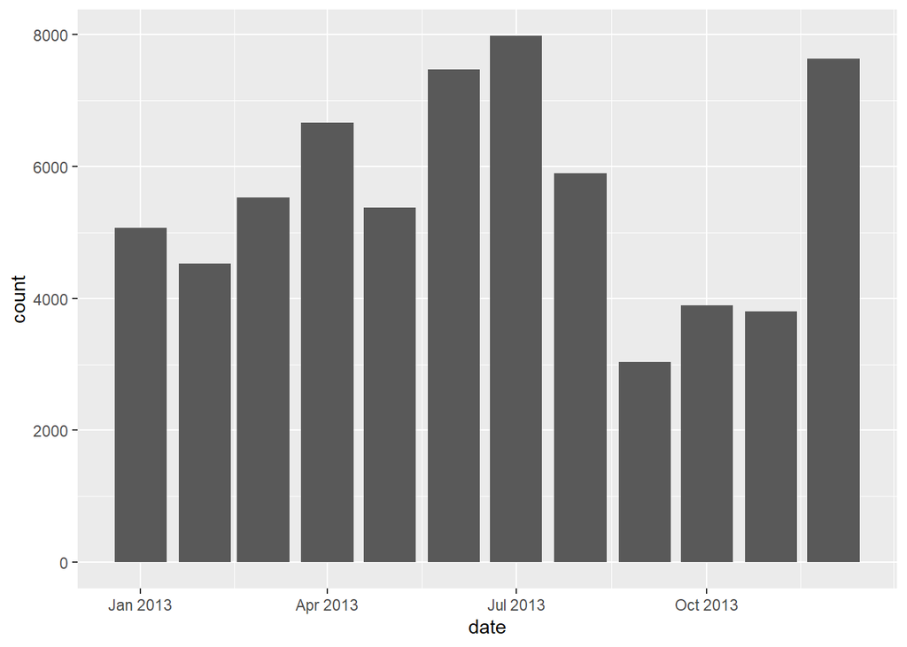

```r
q5_temp <- flight_data[arr_delay > 20, list(date = make_date(year, month))]
ggplot(q5_temp, aes(x = date)) + geom_bar()
```

Plot the departure delay of flights going to IAH and the related day’s wind speed on a scaterplot! Is there any association between the two variables? Try adding a linear model.

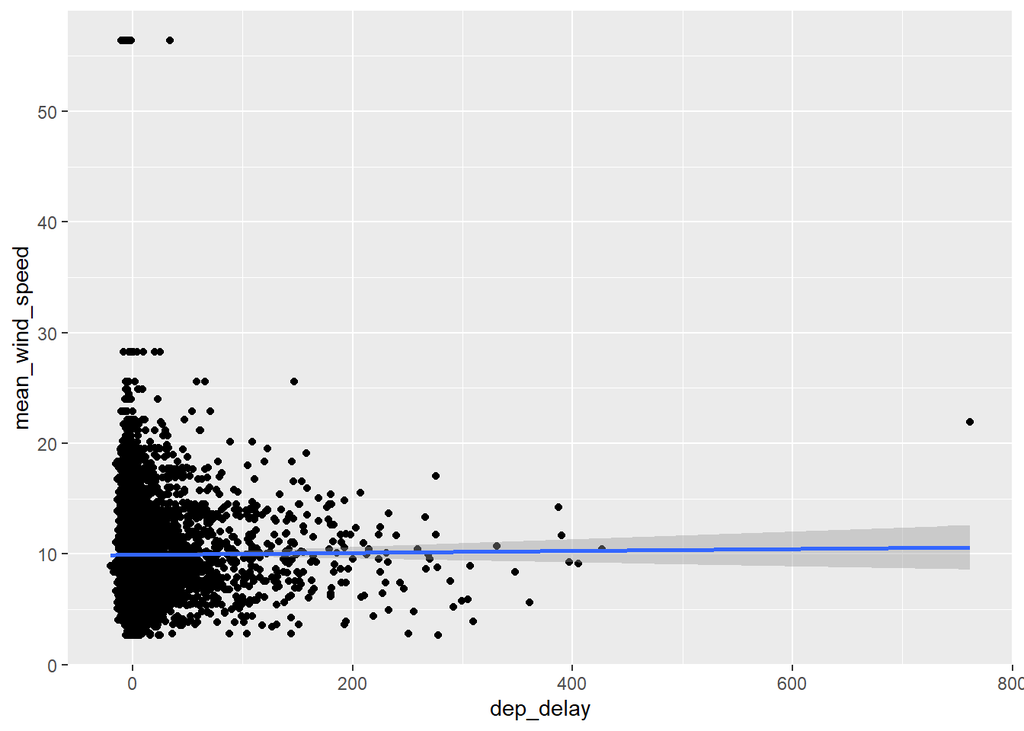

```r
flights_weather <- data.table(nycflights13::weather)

q6_temp <- flight_data[dest == 'IAH',
                       list(dep_delay, origin, dest, year, month, day)]

agg_weather <- flights_weather[, list(mean_wind_speed = mean(wind_speed)),
                               by = list(origin, year, month, day)]

q6_answer <- merge(q6_temp, agg_weather)

ggplot(q6_answer, aes(dep_delay, mean_wind_speed)) +
  geom_point() +
  geom_smooth(method = 'lm')
```

Plot the airports as per their geolocation on a world map, by mapping the number flights going to that destination to the size of the symbol!

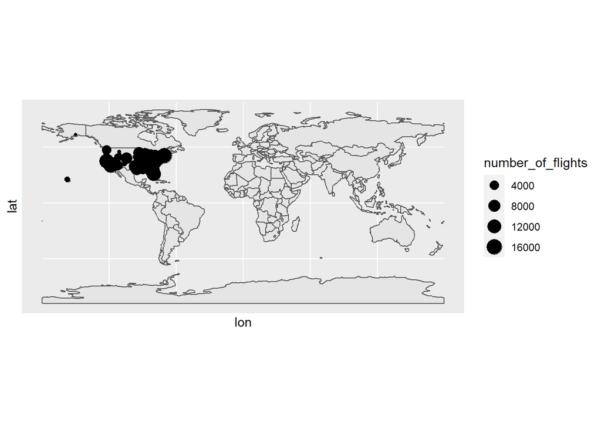

```r
map <- ne_countries(returnclass = "sf")

flight_airports <- data.table(nycflights13::airports)
geo_flight_data <- merge(flight_data[, list(number_of_flights = .N), by = dest],
                         flight_airports[, list(faa, lat, lon)],
                         by.x = "dest", by.y = "faa")

# To answer this question, the following resource was used
# https://www.r-spatial.org/r/2018/10/25/ggplot2-sf.html

ggplot(map) +
  geom_sf() +
  geom_point(data = geo_flight_data, aes(lon,lat, size = number_of_flights))
```

Misi’s alternative answer

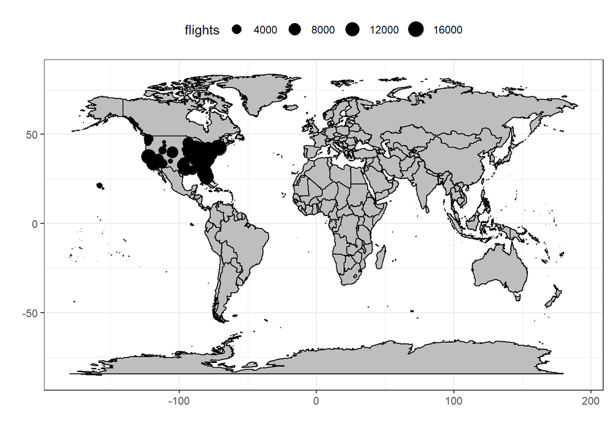

```r
worldmap <- map_data('world')
ggplot() +
  geom_polygon(
    data = worldmap,
    aes(x = long, y = lat, group = group),
    fill = 'gray', color = 'black') +
  geom_point(
    data = merge(
      airports,
      flight_data[, .(flights = .N), by = .(faa = dest)],
      by = 'faa'),
    aes(lon, lat, size = flights)) +
  theme_bw() +
  theme(legend.position = 'top') +
  xlab('') + ylab('') +
  coord_fixed(1.3)
```